# Lab 5 Key

Daniel Anderson

10/14/2018

# Data prep

Copy and paste your code from class to load the hsb2 data into the chunk below. This will get you access to the data within your R Markdown file. Make sure you store your data in an object called `d`.

```r
library(tidyverse)
library(here)
library(rio)
theme_set(theme_minimal())

d <- import(here("data", "hsb2.sav"),
            setclass = "tbl_df") %>%
  characterize()
```

```r
head(d)
```

```
## # A tibble: 6 x 11
##      id race  ses    schtyp prog     read write  math science socst Gender
##   <dbl> <chr> <chr>  <chr>  <chr>   <dbl> <dbl> <dbl>   <dbl> <dbl> <chr>
## 1    70 white low    public general    57    52    41      47    57 Male
## 2   121 white middle public vocati…    68    59    53      63    61 Female
## 3    86 white high   public general    44    33    54      58    31 Male
## 4   141 white high   public vocati…    63    44    47      53    56 Male
## 5   172 white middle public academ…    47    52    57      53    61 Male
## 6   113 white middle public academ…    44    52    51      63    61 Male
```

Knit the file immediately. If you get an error from the chunk below, keep working until your data are loaded correctly (and get help if you need it).

1. Display a histogram of `write`

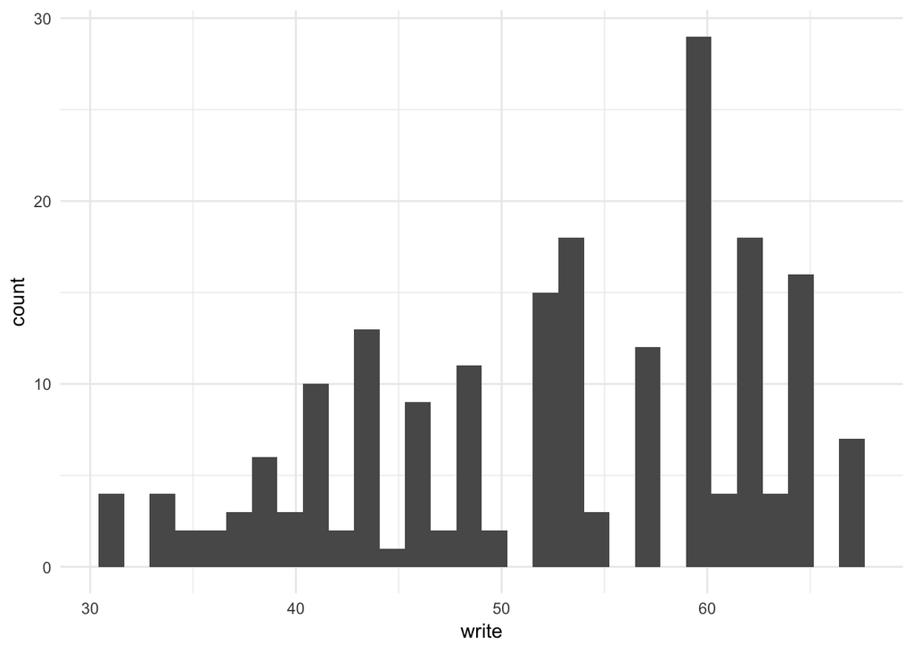

```r
ggplot(d, aes(write)) +
  geom_histogram()
```

Does the distribution approximate normality?

2. Display a scatterplot with `write` on the x-axis and `read` on the y-axis. Display separate plots by `schtyp` (whether the school is private or public) with both a linear and nonlinear regression line overlayed for each.

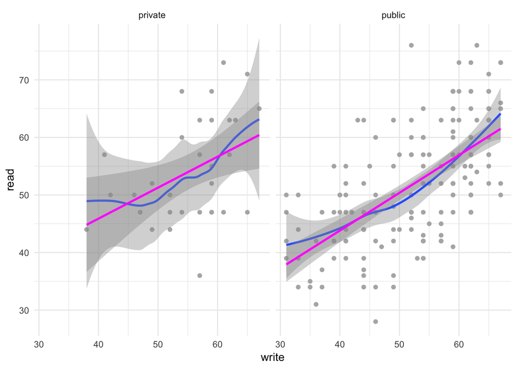

```r
ggplot(d, aes(write, read)) +
  geom_point(color = "gray70") +
  geom_smooth() +
  geom_smooth(method = "lm",
              color = "magenta") +
  facet_wrap(~schtyp)
```

Does assumption of linearity appear tenable in each case?

Does the assumption of homoskedasticity appear tenable?

3. In the code chunk below, fit a model with `schtyp` (whether the school is private or public) and `write` predicting `read`. Set public schools as the reference group.

```r
d <- d %>%
  mutate(schtyp = factor(schtyp),
         schtyp = relevel(schtyp, ref = "public"))

m1 <- lm(read ~ write + schtyp, data = d)
summary(m1)
```

```
##
## Call:
## lm(formula = read ~ write + schtyp, data = d)
##
## Residuals:
##      Min       1Q   Median       3Q      Max
## -19.8197  -5.9901  -0.8197   5.6126  24.3158
##
## Coefficients:
##               Estimate Std. Error t value Pr(>|t|)
## (Intercept)   18.19139    3.31919   5.481 1.29e-07 ***
## write          0.64409    0.06234  10.332  < 2e-16 ***
## schtypprivate  0.29133    1.60779   0.181    0.856
## ---
## Signif. codes:  0 '***' 0.001 '**' 0.01 '*' 0.05 '.' 0.1 ' ' 1
##
## Residual standard error: 8.268 on 197 degrees of freedom
## Multiple R-squared:  0.3562, Adjusted R-squared:  0.3497
## F-statistic: 54.51 on 2 and 197 DF,  p-value: < 2.2e-16
```

Fill out the below, providing your interpretation of each:

The intercept represents: * The average score for students attending public who scored a zero on the writing measure

The coefficeint for `write` represents: * For every one unit increase on the writing measure students scored, on average, 0.64 points higher on the reading measure, when controlling for school type (public versus private).

The standard error around the `write` coefficient indicates: * The uncertainty of the estimate - technically, the standard deviation of the theoretical sampling distribution.

The model accounted for 35% of the variance in reading scores, indicating the joint contribution of school type and writing scores significantly predicted students reading scores ($p < 0.01$).

4. Use the model to calculate confidence intervals around the coefficeints.

```r
confint(m1)
```

```
##                    2.5 %     97.5 %
## (Intercept)   11.6456801 24.7370996
## write          0.5211513  0.7670343
## schtypprivate -2.8793586  3.4620235
```

Interpret the CI for the intercept

5. Produce a plot of the fitted values against the model residuals.

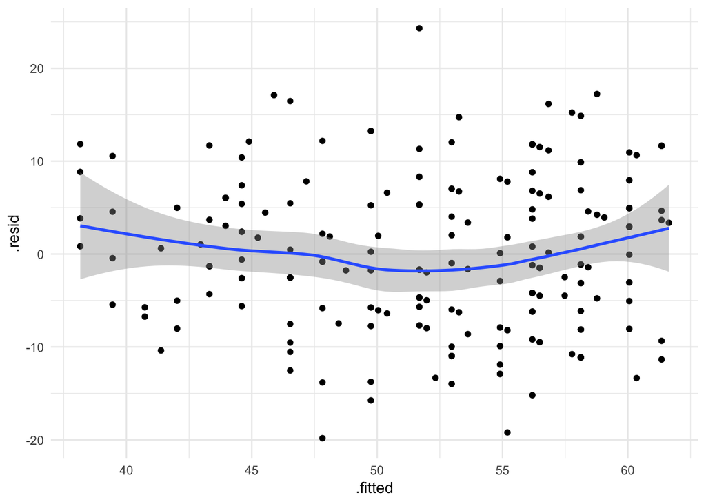

```r
pd <- fortify(m1)

ggplot(pd, aes(.fitted, .resid)) +
  geom_point() +
  geom_smooth()
```

Interpret the plot.

6. Use Cook’s Distance to identify influential cases. What cases are most influential?

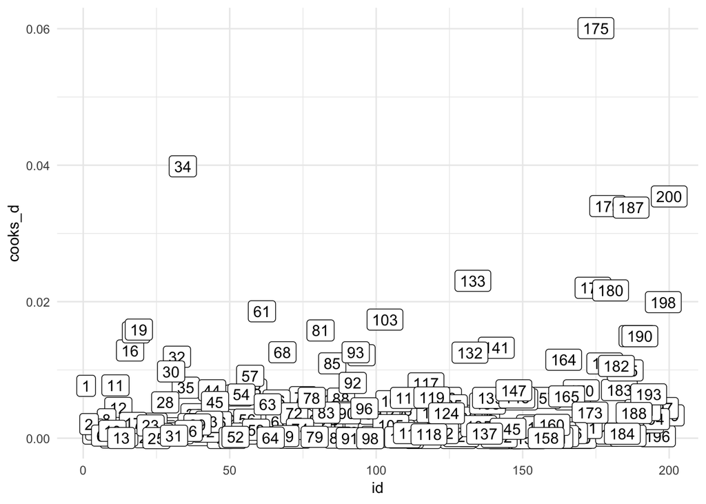

```r
d <- d %>%
  mutate(cooks_d = cooks.distance(m1))

ggplot(d, aes(id, cooks_d)) +
  geom_label(aes(label = id))
```

Case 175 is the most influential. However, the value is somewhere around 0.06, which is very small and likely not unduly influential.